# Initial analysis

Teresa Coimbra

```r
dim(data)
```

```
## [1] 1726   40
```

```r
head(data)
```

|  | ERR4587991 | ERR4587992 | ERR4587993 | ERR4587994 | ERR4587995 | ERR4587996 | ERR4587997 | ERR4587998 | ERR4587999 | ERR4588000 | ERR4588001 | ERR4588002 | SRR390316 | SRR390317 | SRR5860548 | SRR5860549 | SRR5860550 | SRR5860551 | SRR5860552 | SRR5860553 | SRR5860554 | SRR5860555 | SRR5860556 | SRR5860557 | SRR5860558 | SRR5860559 | SRR6112518 | SRR6112538 | SRR6112863 | … |
| --- | --- | --- | --- | --- | --- | --- | --- | --- | --- | --- | --- | --- | --- | --- | --- | --- | --- | --- | --- | --- | --- | --- | --- | --- | --- | --- | --- | --- | --- | --- |
| STER_RS00005 | 1840 | 2046 | 1890 | 2051 | 1828 | 1721 | 1865 | 1907 | 1526 | 1892 | 2025 | 1820 | 2587 | 2811 | 2239 | 2118 | 1895 | 1846 | 2547 | 3729 | 2359 | 2676 | 2528 | 2607 | 2903 | 2599 | 7849 | 4589 | 6038 | … |
| STER_RS00010 | 2676 | 2928 | 2835 | 3022 | 2686 | 2667 | 2718 | 2919 | 2243 | 2657 | 2805 | 2743 | 3356 | 3934 | 3264 | 2814 | 2561 | 2625 | 3237 | 4787 | 2745 | 3227 | 3119 | 3398 | 3281 | 2913 | 10246 | 4227 | 6060 | … |
| STER_RS00015 | 4 | 6 | 5 | 6 | 6 | 5 | 5 | 5 | 4 | 4 | 4 | 3 | 0 | 0 | 0 | 0 | 0 | 0 | 0 | 0 | 0 | 0 | 0 | 0 | 0 | 0 | 0 | 0 | 0 | … |
| STER_RS00020 | 60 | 57 | 60 | 50 | 65 | 57 | 48 | 58 | 65 | 52 | 55 | 89 | 257 | 276 | 125 | 100 | 98 | 86 | 138 | 155 | 96 | 123 | 132 | 125 | 129 | 135 | 197 | 163 | 323 | … |
| STER_RS00025 | 3689 | 3641 | 3552 | 3344 | 3414 | 3378 | 3263 | 3390 | 3517 | 3662 | 3729 | 3427 | 4282 | 5047 | 4379 | 4069 | 3897 | 3951 | 3564 | 4324 | 3538 | 4127 | 3666 | 3242 | 3325 | 3736 | 3613 | 2627 | 2502 | … |
| STER_RS00030 | 293 | 314 | 253 | 399 | 350 | 344 | 311 | 279 | 213 | 323 | 348 | 270 | 262 | 295 | 123 | 265 | 245 | 238 | 136 | 144 | 132 | 162 | 143 | 162 | 160 | 129 | 427 | 712 | 345 | … |

```r
head(meta_data)
```

|  | files | medium | environmental_cond | genetic_cond | growth_phase | strain | dataset | Replicate | detail |
| --- | --- | --- | --- | --- | --- | --- | --- | --- | --- |
| ERR4587991 | ERR4587991_count.txt | CD | Chemically defined medium 42deg | delta comR delta amiCDE | Late-exponential | LMD-9 | PRJEB40341 | 1 | ERR4C1 |
| ERR4587992 | ERR4587992_count.txt | CD | Chemically defined medium 42deg | delta comR delta amiCDE | Late-exponential | LMD-9 | PRJEB40341 | 2 | ERR4C1 |
| ERR4587993 | ERR4587993_count.txt | CD | Chemically defined medium 42deg | delta comR delta amiCDE | Late-exponential | LMD-9 | PRJEB40341 | 3 | ERR4C1 |
| ERR4587994 | ERR4587994_count.txt | CD | Chemically defined medium 42deg | delta comR delta eep | Late-exponential | LMD-9 | PRJEB40341 | 1 | ERR4C2 |
| ERR4587995 | ERR4587995_count.txt | CD | Chemically defined medium 42deg | delta comR delta eep | Late-exponential | LMD-9 | PRJEB40341 | 2 | ERR4C2 |
| ERR4587996 | ERR4587996_count.txt | CD | Chemically defined medium 42deg | delta comR delta eep | Late-exponential | LMD-9 | PRJEB40341 | 3 | ERR4C2 |

On the data file the columns correspond to run accessions and the rows to the locus tags. All the columns have a corresponding row in the metadata file.

```r
all.equal(colnames(data),rownames(meta_data))
```

```
## [1] TRUE
```

# Hierarchical clustering

Datasets are organized into clusters

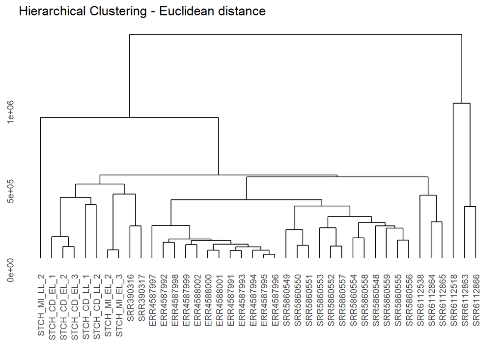

```r
df_t = t(data)
distxy <- dist(df_t, method = "euclidean")
hc = hclust(distxy,method='average')
ggdendrogram(hc, theme_dendro = TRUE)+
  ggtitle("Hierarchical Clustering - Euclidean distance")
```

```r
phenoData <- new("AnnotatedDataFrame",data=meta_data)
DF = ExpressionSet(assayData=as.matrix(data), phenoData=phenoData)
```

### PCA

```r
p <- pca(data, metadata = meta_data, removeVar = 0.1)
```

```
## -- removing the lower 10% of variables based on variance
```

Using the elbow point method, the number of principal components to retain is 6.

```r
elbow <- findElbowPoint(p$variance)
elbow
```

```
## PC6
##   6
```

By looking at the principal components that contribute to 90% of the explained variation, the number of PCs to retain is 4:

```r
which(cumsum(p$variance) > 90)[1]
```

```
## PC4
##   4
```

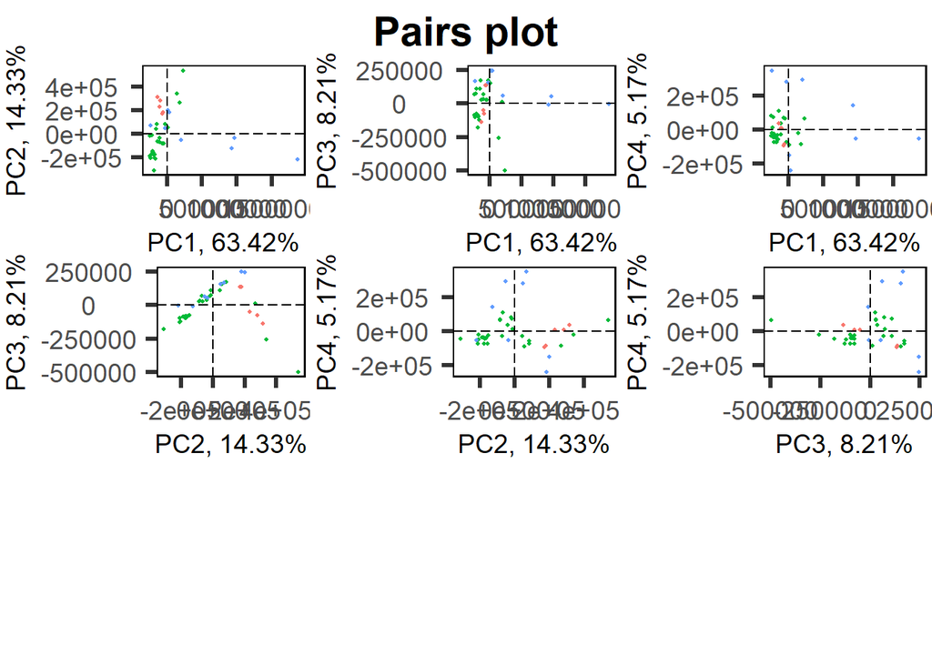

```r
pairsplot(p,
    components = getComponents(p, c(1,2,3,4)),
    triangle = FALSE,
    hline = 0, vline = 0,
    pointSize = 0.8,
    gridlines.major = FALSE, gridlines.minor = FALSE,
    colby = 'growth_phase',
    title = 'Pairs plot', titleLabSize = 22,
    axisLabSize = 14, plotaxes = TRUE)
```

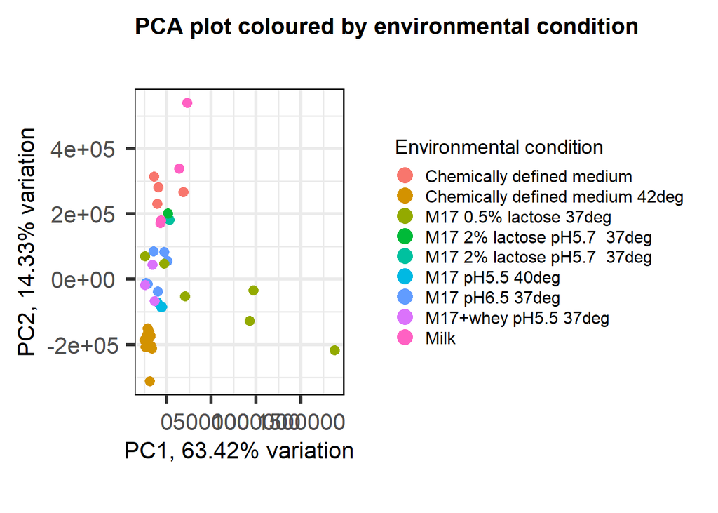

```r
biplot(p,
    colby = 'environmental_cond',
    colLegendTitle = "Environmental condition",
    legendPosition = 'right',
    title = 'PCA plot coloured by environmental condition',
    lab = NULL)
```

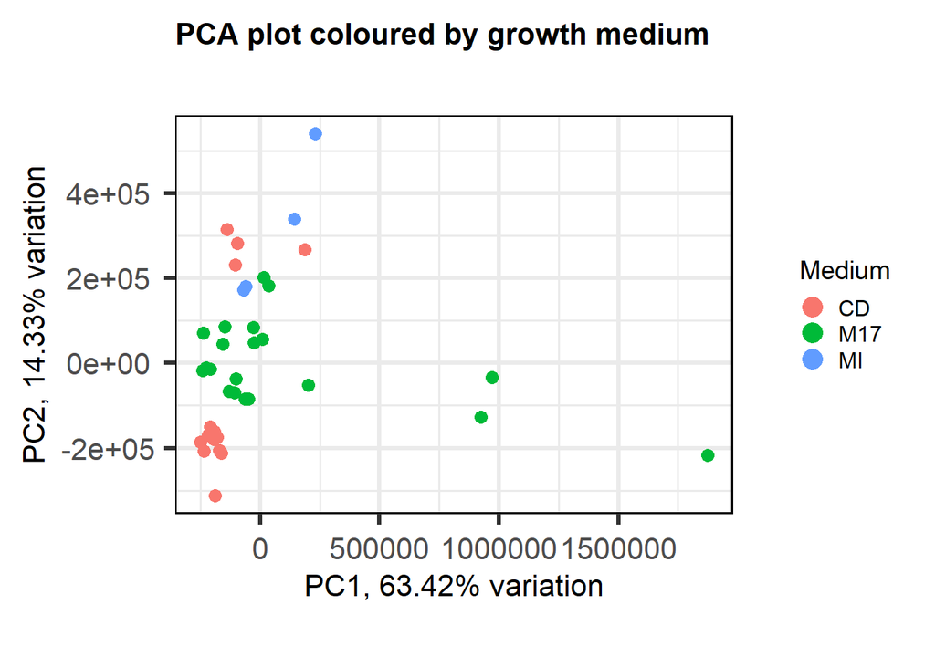

```r
biplot(p,
    colby = 'medium',
    colLegendTitle = "Medium",
    legendPosition = 'right',
    title = 'PCA plot coloured by growth medium',
    lab = NULL)
```

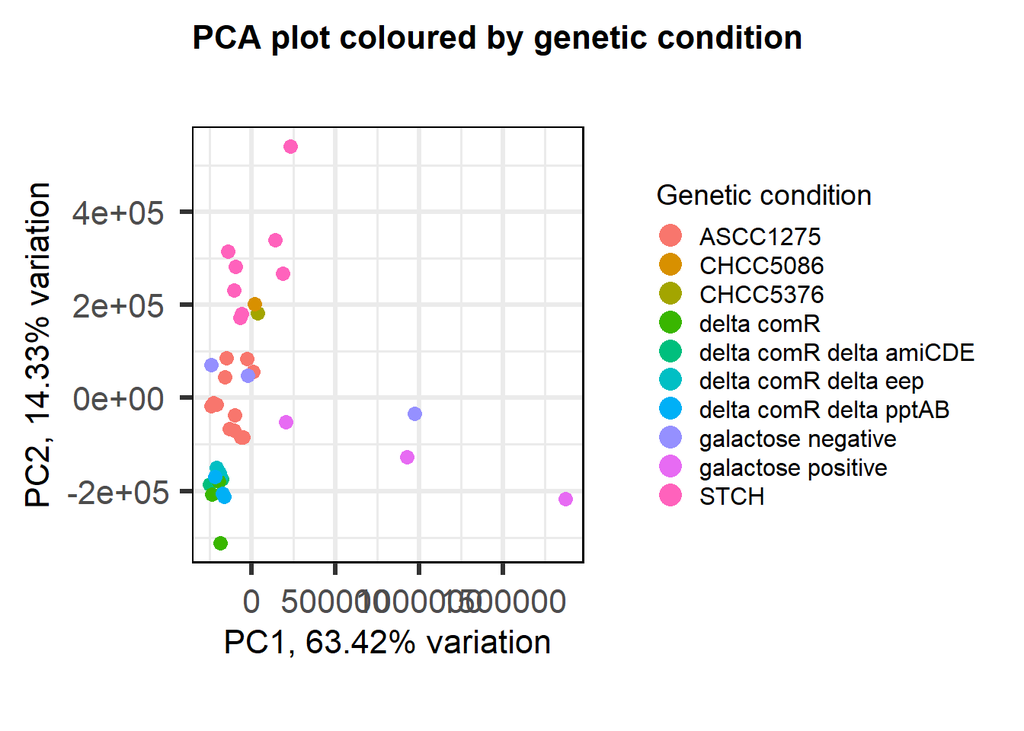

```r
biplot(p,
    colby = 'genetic_cond',
    colLegendTitle = 'Genetic condition',
    legendPosition = 'right',
    title = 'PCA plot coloured by genetic condition',
    lab = NULL)
```

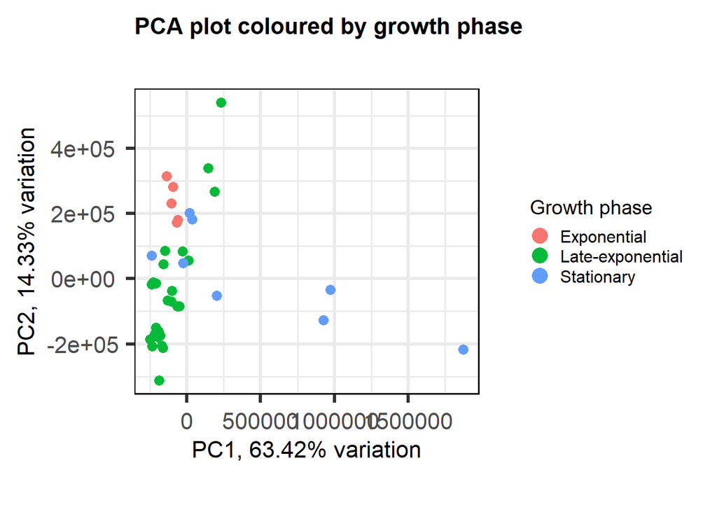

```r
biplot(p,
    colby = 'growth_phase',
    legendPosition = 'right',
    title = 'PCA plot coloured by growth phase',
    colLegendTitle = 'Growth phase',
    lab = NULL)
```

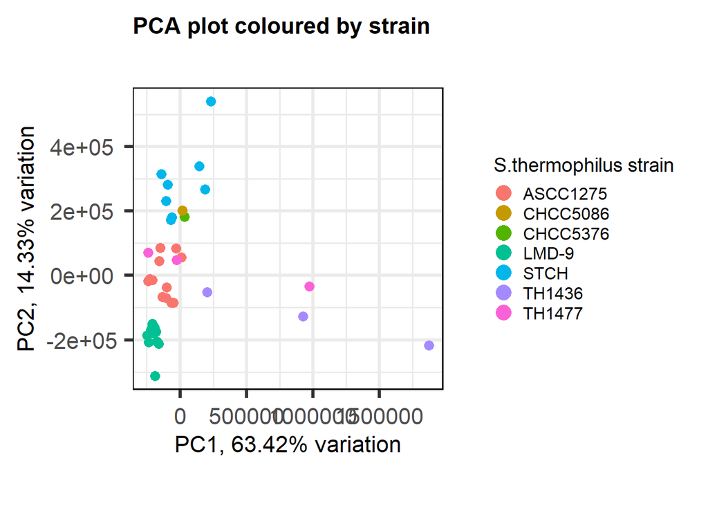

```r
biplot(p,
    colby = 'strain',
    legendPosition = 'right',
    title = 'PCA plot coloured by strain',
    colLegendTitle = 'S.thermophilus strain',
    lab = NULL)
```

```r
df1 = exprs(DF)
df1 = df1[!(apply(df1, 1, function(y) any(y == 0))),]
coloring <- colorRampPalette(brewer.pal(n=8, "RdBu"))(25)
```

Predominance of a negative correlation between samples and genes.

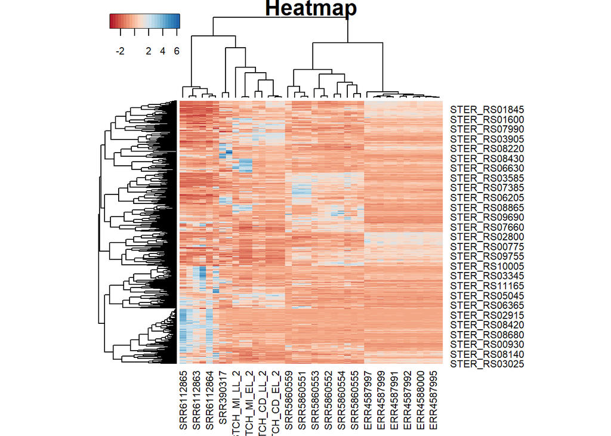

```r
heatmap3(df1, col=coloring, scale = "row", main = "Heatmap")
```

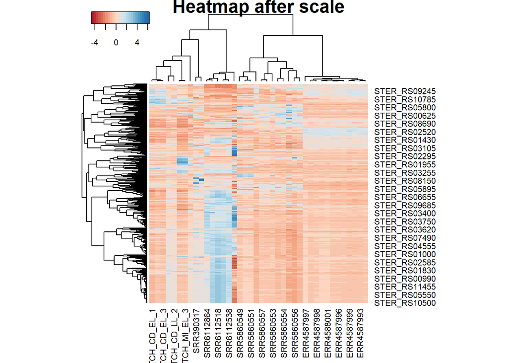

```r
s_df = scale(df1)
heatmap3(s_df, col=coloring, scale = "row", main = "Heatmap after scale")
```

The heatmap bellow shows the first 25 genes across the all the samples of the dataset PRJEB40341. The first gene with the locus tag “STER_RS00070” is the ftsH gene which codes for an ATP-dependent zinc metalloprotease called FtsH. In this dataset, all samples have suffered a knockout on the comR gene. This is a copper outer membrane regulator. There can be a relation regarding these genes and their functions, which could be interesting to be explored.

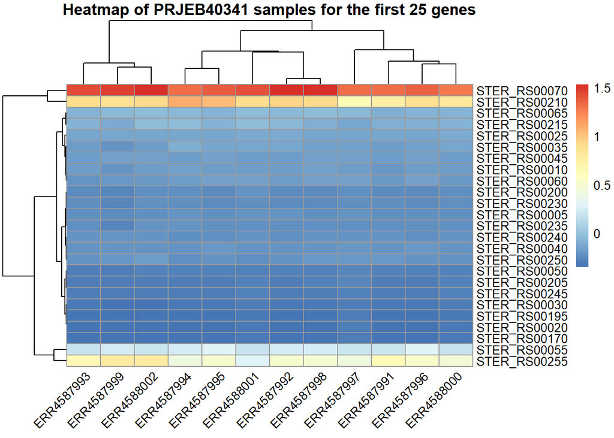

```r
pheatmap(s_df[1:25,1:12], angle_col = 45, main='Heatmap of PRJEB40341 samples for the first 25 genes')
```

### K-means

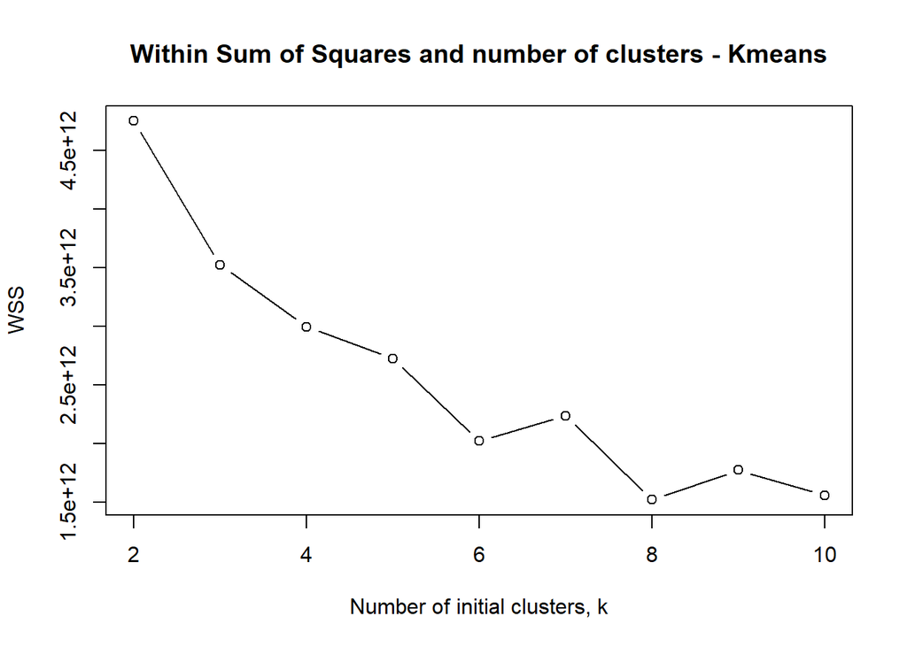

```r
set.seed(12345)
ofs = c()
for (k in 2:10) ofs[k] = sum(kmeans(df_t, centers=k)$withinss)
plot(2:10, ofs[2:10], type="b", xlab="Number of initial clusters, k", ylab="WSS",main='Within Sum of Squares and number of clusters - Kmeans')
```

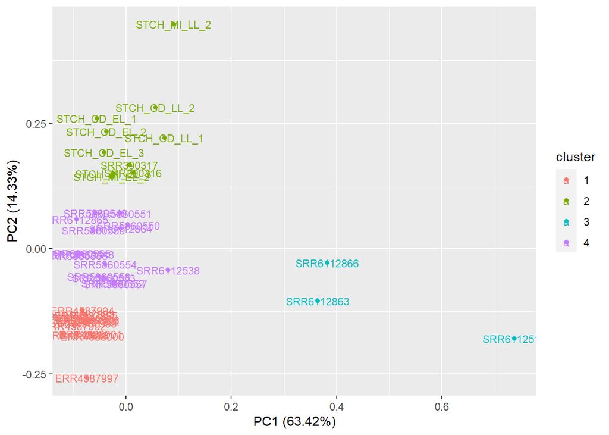

```r
autoplot(kmeans(df_t, 4), data = df_t, label = TRUE, label.size = 3)
```